# Illustrate the initial phenotypes

Bin He, Hanxi Tang

2024-09-05 (updated 2025-04-14 11:29:54.366907)

# Background

This folder contains analyses for showing the initial staining patterns we observed when applying FungaLight to oxidative stress damaged *C. glabrata* cells. Note that these are not exactly our first trial results, which suffer a lot more inconsistencies and abnormalities, due to our inexperience with the reagent and protocol in general. Rather, these are the “alpha” tests of the protocol after some preliminary tests, and represent at least “sensible” results, although with important caveats that we addressed in the later protocol optimization steps.

```r
require(flowCore)
require(flowClust)
require(openCyto)
require(ggcyto)
require(tidyverse)
require(cowplot)
require(ggridges)
```

```r
old <- theme_set(theme_minimal())
```

# Import data

> FCS files are stored in RDSS/user/flow cytometry, FCS is read and write into an input tsv table. The tsv file is avaliable from the Input folder.

```r
# use relative path to make it easier for collaboration
data.path = "../input/20230929 FungaLight-Cgla-analysis/"
dat0 <- read.flowSet(path = data.path, transformation = FALSE,  # the original values are already linearized.
                     emptyValue = FALSE,  alter.names = TRUE,   # change parameter names to R format
                     column.pattern = ".H|FSC|SSC") # only load the height variables for the fluorescent parameters
```

## Simplify the sample names

```r
#source("../../../00-Shared/01-script/20220326-simplify-names-subroutine.R")
oriNames <- sampleNames(dat0)
tmp <- str_split(oriNames, pattern = "_", simplify = TRUE)[,c(1, 5)]
colnames(tmp) <- c("Date", "Treatment")
sample <- data.frame(tmp) %>%
  mutate(
    date = mdy(Date),
    replicate = ifelse(str_sub(Treatment, 1, 1) == "B", "B", "A"),
    treatment = sub("B ", "", Treatment) %>% sub(".fcs", "", .) %>%
      gsub("1M", "1000", .) %>% gsub("Mock", "0", .),
    treatment = factor(treatment, levels = sort(as.numeric(unique(treatment))))
  ) %>%
  select(-Date, - Treatment)
tr.levels <- levels(sample$treatment)
rownames(sample) <- oriNames
dat <- dat0 # make a copy
pData(dat) <- sample
print(pData(dat) %>% as_tibble())
```

| date | replicate | treatment | name |
| --- | --- | --- | --- |
| 2023-09-15 | A | 10 | 091523_Cg log FGL_Experiment_Plate_10.fcs |
| 2023-09-15 | A | 100 | 091523_Cg log FGL_Experiment_Plate_100.fcs |
| 2023-09-15 | A | 1000 | 091523_Cg log FGL_Experiment_Plate_1M.fcs |
| 2023-09-15 | A | 2 | 091523_Cg log FGL_Experiment_Plate_2.fcs |
| 2023-09-15 | A | 20 | 091523_Cg log FGL_Experiment_Plate_20.fcs |
| 2023-09-15 | A | 4 | 091523_Cg log FGL_Experiment_Plate_4.fcs |
| 2023-09-15 | A | 40 | 091523_Cg log FGL_Experiment_Plate_40.fcs |
| 2023-09-15 | A | 6 | 091523_Cg log FGL_Experiment_Plate_6.fcs |
| 2023-09-15 | A | 60 | 091523_Cg log FGL_Experiment_Plate_60.fcs |
| 2023-09-15 | A | 8 | 091523_Cg log FGL_Experiment_Plate_8.fcs |

[output cut: 61 more lines]

```r
write_tsv(pData(dat), file = "../input/20230929-sample-list.tsv")
```

# Basic gating

## Outlier

The following gaphing steps are used to gate singlets by FSC and SSC values. Only singlets are included in analysis.

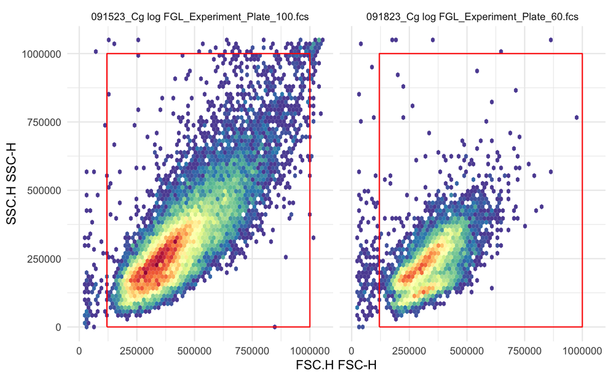

```r
outlier.gate <- rectangleGate(filterId = "-outlier", "FSC.H" = c(1.2e5, 1e6), "SSC.H" = c(1e2, 1e6))
ggcyto(dat[c(2,20)], aes(x = FSC.H, y = SSC.H), subset = "root") +
  geom_hex(bins = 64) + geom_gate(outlier.gate) + facet_wrap(~name, ncol = 2) + ggcyto_par_set(limits = "instrument")
```

```r
# ----
# uncomment the code below to check on all data
# ----
# ggcyto(dat, aes(x = FSC.H, y = SSC.H), subset = "root") +
#   geom_hex(bins = 64) + geom_gate(outlier.gate) + facet_wrap(~name, ncol = 9) + ggcyto_par_set(limits = "instrument") +
#   theme_minimal_grid()
# ----
# end
# ----
```

Add gate to GS

```r
# shorten the names of the samples for plotting
shortNames <- with(pData(dat),
                   paste(substr(date, 6, 10), replicate,
                         paste0(treatment, "mM"), sep = "_"))
names(shortNames) <- sampleNames(dat)
gs <- GatingSet(dat) # create a GatingSet
# rename the GatingSet
if(all(sampleNames(gs) == names(shortNames)))
  pData(gs)$name <- shortNames
# add the outlier gate
gs_pop_add(gs, outlier.gate, parent = "root")
```

```
[1] 2
```

```r
# compute
recompute(gs)
```

```
done!
```

## Gate for singlets

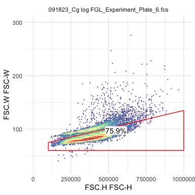

```r
scPars <- ggcyto_par_set(limits = list(x = c(0,1e6), y = c(30,300)))
ex <- Subset(dat[[19]], outlier.gate)
polygon <- matrix(c(1e5, 1e5, 1e6, 1e6,
                    60, 75, 135,60), ncol = 2)
colnames(polygon) <- c("FSC.H", "FSC.W")
singlet.gate <- polygonGate(filterId = "singlet", .gate = polygon)
ggcyto(ex, aes(x = FSC.H, y = FSC.W)) + geom_hex(bins = 128) + geom_gate(singlet.gate) + geom_stats() + scPars
```

Add this gate to the gatingSet

```r
gs_pop_add(gs, singlet.gate, parent = "-outlier", name = "singlet")
```

```
[1] 3
```

```r
recompute(gs)
```

```
done!
```

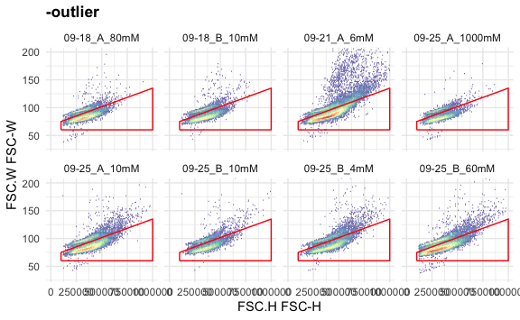

```r
scPars <- ggcyto_par_set(limits = list(x = c(0,1e6), y = c(30,200)))
test <- sample(1:length(gs), 8)
ggcyto(gs[test], aes(x = FSC.H, y = FSC.W), subset = "-outlier") +
  geom_hex(bins = 128) + geom_gate("singlet") + facet_wrap(~name, ncol = 4) +
  scPars# + theme(strip.text = element_blank())
```

Check number of events after gating

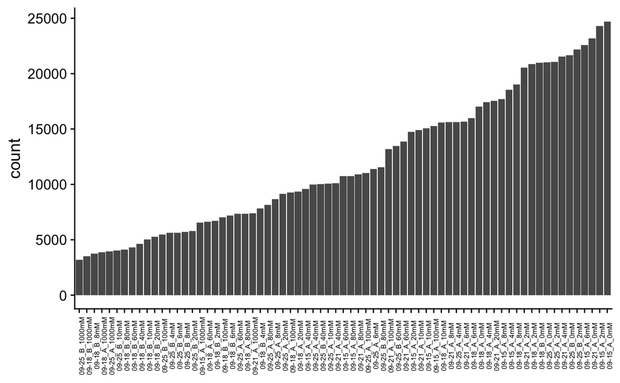

```r
gated_events <- gs_pop_get_stats(gs, "singlet") %>%
  left_join(pData(gs) %>% rownames_to_column(var = "sample"), by = "sample") %>%
  arrange(count)

gated_events %>%
  mutate(name = fct_reorder(name, count)) %>%
  ggplot(aes(x = name, y = count)) +
  geom_col() +
  theme_cowplot() + xlab(NULL) +
  theme(
    axis.text.x = element_text(angle = 90, size = rel(0.5))
  )
```

## FSC and SSC vs treatment and dye

### FSC

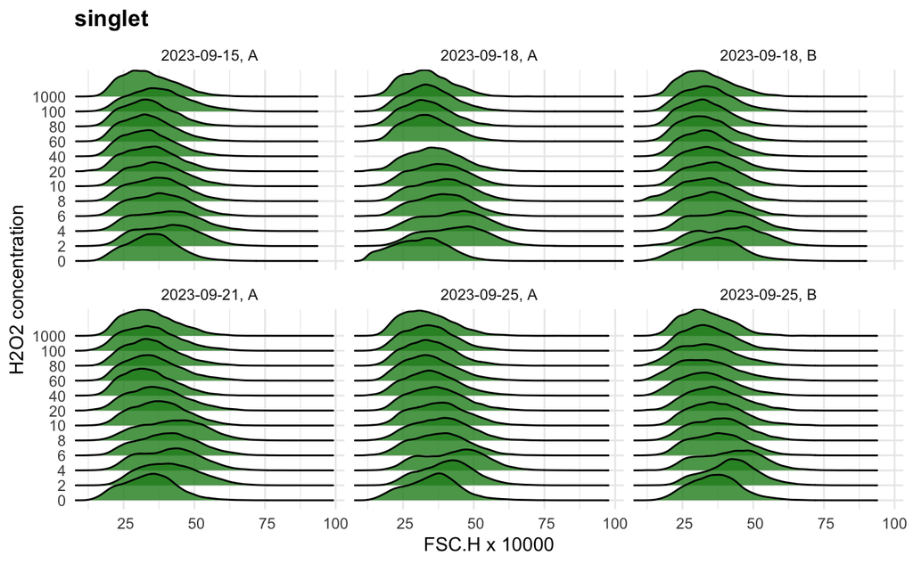

```r
mult_format <- function() {
     function(x) format(x/10000,digits = 2)
}
#for(date in unique(sample$date)){
p <- ggcyto(gs, aes(x = FSC.H), subset = "singlet") +
  geom_density_ridges(aes(y = factor(treatment, levels = tr.levels)),
                      fill = "forestgreen", alpha = 0.8) +
  scale_x_continuous(labels = mult_format(), name = "FSC.H x 10000") +
  facet_wrap(~date + replicate,
             labeller = labeller(.multi_line = FALSE)) +
  ylab("H2O2 concentration")
print(p)
#}
ggsave("../output/20250414-h2o2-treatment-alter-FSC.png", width = 4, height = 4)
```

> interestingly, low doses of H2O2 (2-8 mM) appears to cause cell expansion, while >10 mM H2O2 treatment causes cell shrinkage

### SSC

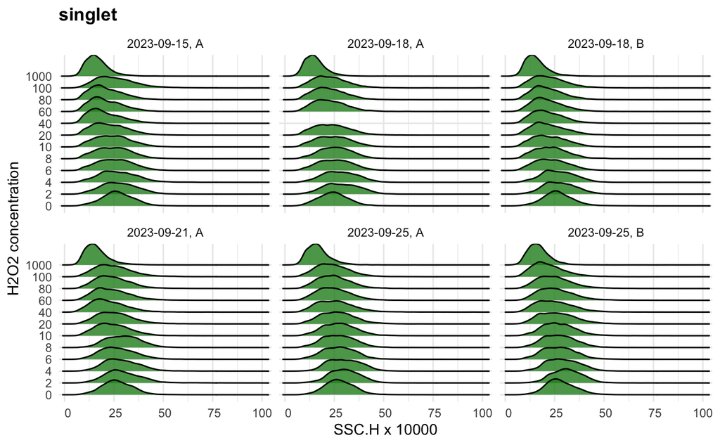

```r
  p <- ggcyto(gs, aes(x = SSC.H), subset = "singlet") +
    geom_density_ridges(aes(y = factor(treatment, levels = tr.levels)),
                            fill = "forestgreen", alpha = 0.8) +
    scale_x_continuous(labels = mult_format(), name = "SSC.H x 10000") +
    facet_wrap(~date + replicate,
               labeller = labeller(.multi_line = FALSE)) +
    ylab("H2O2 concentration")
  print(p)

ggsave("../output/20250414-h2o2-treatment-alter-SSC.png", width = 4, height = 4)
```

> SSC (complexity of cell, roughly) decreases with increasing H2O2 concentration

### BL1.H (green staining)

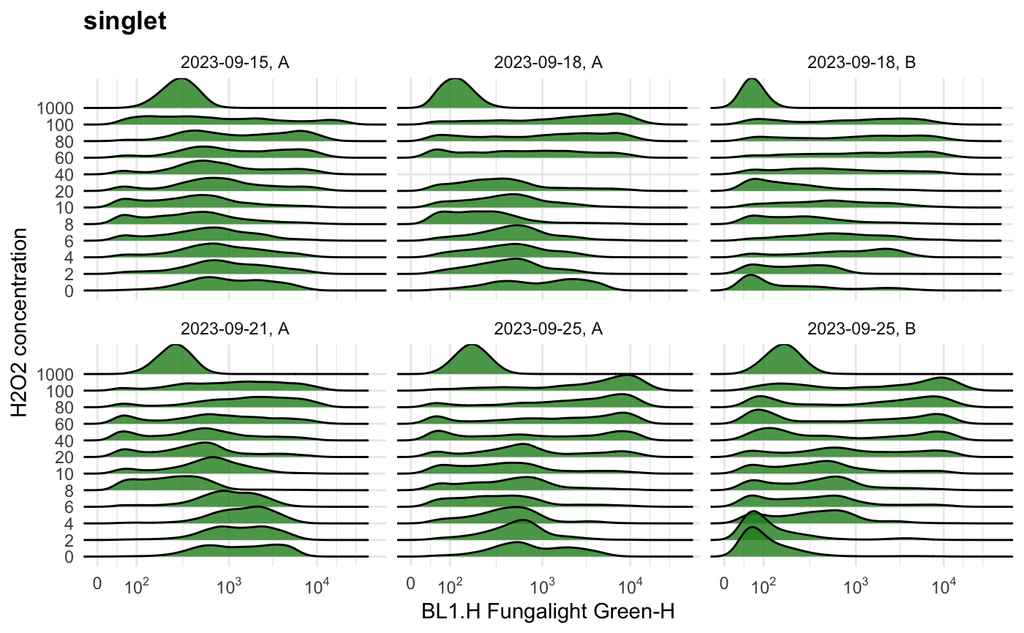

```r
#for(date in c("011124", "011524", "011624")){
  p <- ggcyto(gs, aes(x = BL1.H), subset = "singlet") +
    geom_density_ridges(aes(y = factor(treatment, levels = tr.levels)),
                            fill = "forestgreen", alpha = 0.8) +
    scale_x_logicle() +
    facet_wrap(~date + replicate,
               labeller = labeller(.multi_line = FALSE)) +
    ylab("H2O2 concentration")
  print(p)
#}
ggsave("../output/20250414-h2o2-treatment-FGL-green-evolution.png",
       width = 4, height = 4)
```

### BL3.H (red staining)

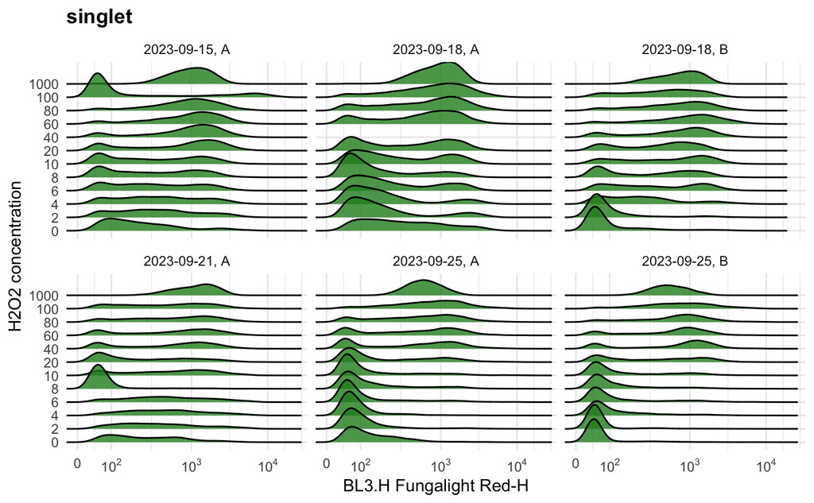

```r
#for(date in c("011124", "011524", "011624")){
  p <- ggcyto(gs, aes(x = BL3.H), subset = "singlet") +
    geom_density_ridges(aes(y = factor(treatment, levels = tr.levels)),
                            fill = "forestgreen", alpha = 0.8) +
    scale_x_logicle() +
    facet_wrap(~date + replicate,
               labeller = labeller(.multi_line = FALSE)) +
    ylab("H2O2 concentration")
  print(p)
#}
ggsave("../output/20250414-h2o2-treatment-FGL-red-evolution.png",
       width = 4, height = 4)
```

# Plotting initial phenotype

Here, we plot the G+R staining patterns from multiple days to observe the consistency of the assay

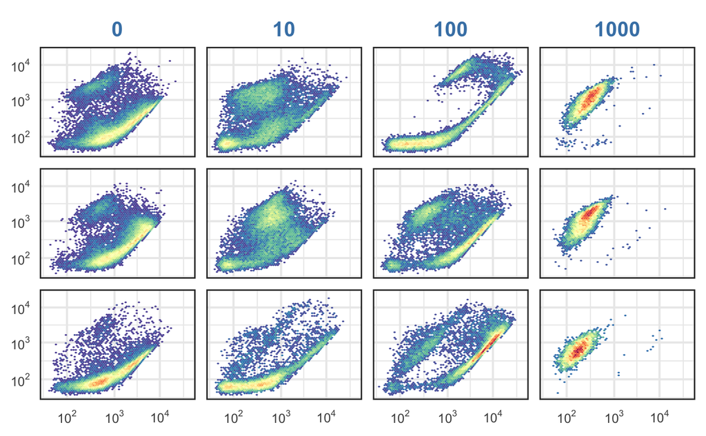

```r
subset.to.plot <- pData(gs)$replicate == "A" &
  pData(gs)$treatment %in% c("0", "10", "100", "1000") &
  pData(gs)$date != "2023-09-18"
p <- ggcyto(gs[subset.to.plot],
            aes(x = BL1.H, y = BL3.H), subset = "singlet") +
  geom_hex(aes(fill = after_stat(density)), bins = 64) +
  facet_grid(date ~ factor(treatment, levels = tr.levels),
             labeller = labeller(.multi_line = F)) +
  scale_x_logicle(breaks = c(10^2, 10^3, 10^4)) +
  scale_y_logicle(breaks = c(10^2, 10^3, 10^4)) +
  theme_minimal(base_size = 16) +
  panel_border(color = "gray20") + #background_grid(major = "none", minor = "none") +
  theme(
    #axis.line = element_blank(),
    strip.text.y = element_blank(),
    strip.text.x = element_text(size = rel(1.2), color = "steelblue", face = 2),
    axis.text = element_text(size = rel(0.6)),
    plot.title = element_blank(),
    legend.position = "none",
    axis.title = element_blank()
  )

p
ggsave("../output/fig1-staining-consistency-20240911.png", width = 5, height = 4)
```

## Quantify the dead like population in the mock treated sample

We notice that the mock-treated samples contain a subpopulation of “dead-like” cells, whose abundance vary between replicates. We would like to quantify their amount using a gate.

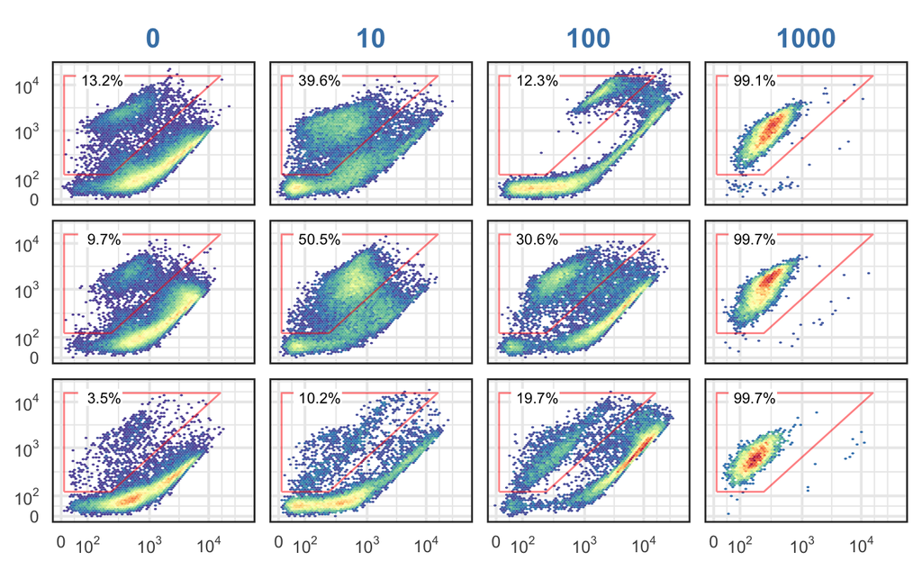

```r
#scPars <- ggcyto_par_set(limits = list(x = c(0,1e6), y = c(0,1e5)))
polygon <- matrix(c(10, 10^2.4, 10^4.2, 10,
                    10^2.1, 10^2.1, 10^4.2, 10^4.2), ncol = 2)
colnames(polygon) <- c("BL1.H", "BL3.H")
deadlike.gate <- polygonGate(filterId = "deadlike", .gate = polygon)
#for(date in c("011124", "011524", "011624")){
p <- ggcyto(gs[subset.to.plot],
            aes(x = BL1.H, y = BL3.H), subset = "singlet") +
  geom_hex(aes(fill = after_stat(density)), bins = 64) +
  geom_gate(deadlike.gate, linewidth = 0.5, alpha = 0.5) +
  geom_stats(location = "gate", adjust = c(0.01, 0.8), digits = 2, size = 3) +
  #labs(title = paste0("Date: ", date)) +
  facet_grid(date ~ factor(treatment, levels = tr.levels)) +
  scale_x_logicle() + scale_y_logicle() +
  theme_minimal(base_size = 16) +
  panel_border(color = "gray20") + #background_grid(major = "none", minor = "none") +
  theme(
    #axis.line = element_blank(),
    strip.text.y = element_blank(),
    strip.text.x = element_text(size = rel(1.2), color = "steelblue", face = 2),
    axis.text = element_text(size = rel(0.6)),

    plot.title = element_blank(),
    legend.position = "none",
    axis.title = element_blank()
  )
print(p)
ggsave("../output/fig1-staining-consistency-gated-20240913.png", width = 5, height = 4)
```

Add this gate to the gatingSet